# Exploring target variable and response rates

Bradley McKenzie

June 2025

## Purpose

Generate a plot of the weighted trends of people who have more support for EU, more support for UK or equal support over all available rounds. Check for not just trends but also polarisation if fewer people are beginning to have stronger views.

### Call the underlying scripts to generate data:

Call data - we use the ess raw data set as it’s much faster to call our data creation and we don’t need demorgaphic information in this code.

Additional libraries:

```r
library(DataExplorer)
library(survey)
library(srvyr)
```

Now we want to create a variable based on the difference in trust in the UK Parliament and trust in the EU Parliament. We don’t care if this is +10 or +1. Just if there is even a difference of opinion.

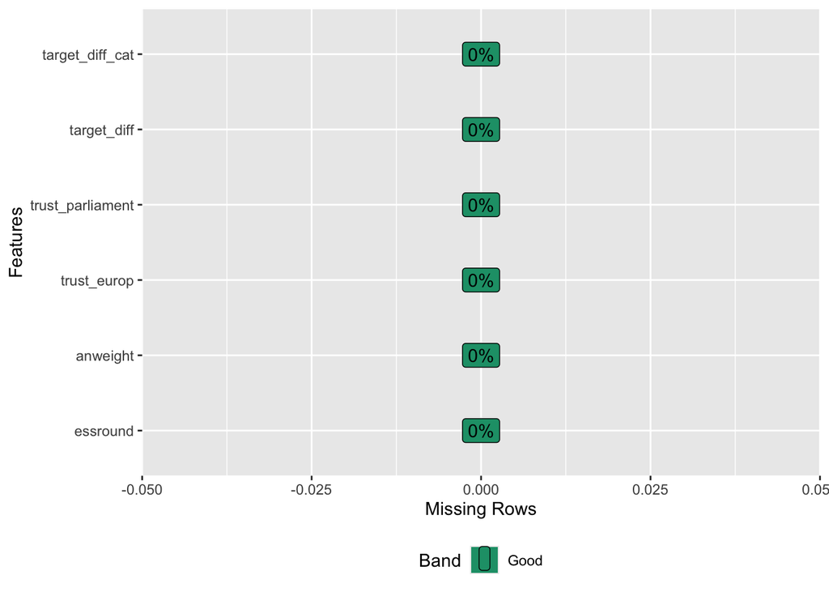

```r
target_explore <- ess_data |>
  filter(cntry == "GB") |>
  select(essround, anweight, trust_europ, trust_parliament) |>
  drop_na() |> # can't keep any missing values for these calculations.
  mutate(target_diff = trust_europ - trust_parliament,
         # now conditional variable:
         target_diff_cat = factor(case_when(target_diff > 0 ~ "Greater EU support",
                                     target_diff == 0 ~ "Equal support",
                                     target_diff < 0 ~ "Greater UK support"),
                                     levels = c("Greater UK support", "Equal support", "Greater EU support"))
  )
target_explore |> plot_missing()
```

```r
target_explore
```

| essround | anweight | trust_europ | trust_parliament | target_diff | target_diff_cat |
| --- | --- | --- | --- | --- | --- |
| 1 | 2.263529539 | 8 | 7 | 1 | Greater EU support |
| 1 | 3.852785587 | 7 | 5 | 2 | Greater EU support |
| 1 | 2.069226980 | 3 | 3 | 0 | Equal support |
| 1 | 4.527059078 | 5 | 7 | -2 | Greater UK support |
| 1 | 3.852785587 | 4 | 3 | 1 | Greater EU support |
| 1 | 2.069226980 | 3 | 2 | 1 | Greater EU support |
| 1 | 3.852785587 | 2 | 3 | -1 | Greater UK support |
| 1 | 3.590479851 | 5 | 5 | 0 | Equal support |
| 1 | 3.333598852 | 0 | 0 | 0 | Equal support |
| 1 | 3.333598852 | 2 | 3 | -1 | Greater UK support |

[output cut: 9990 more lines]

Calculate correlation over time - seems like biggest drop is around R10.

```r
target_explore |>
  group_by(essround) |>
  summarise(correl = cor(trust_europ, trust_parliament))
```

| essround | correl |
| --- | --- |
| 1 | 0.5304974 |
| 2 | 0.5618914 |
| 3 | 0.5716985 |
| 4 | 0.5894295 |
| 5 | 0.5997946 |
| 6 | 0.5738108 |
| 7 | 0.5129634 |
| 8 | 0.5120268 |
| 9 | 0.5482797 |
| 10 | 0.3903769 |

[output cut: 1 more lines]

```r
cor(target_explore$trust_europ, target_explore$trust_parliament)
```

```
## [1] 0.534713
```

## Plot distribution of the target

```r
target_explore <- target_explore |>
  mutate(trust_eu2 = ifelse(trust_europ == 0, 0.1, trust_europ),
         trust_parl2 = ifelse(trust_parliament == 0, 0.1, trust_parliament),
         target_ratiolog_unafj = log(trust_europ/trust_parliament),
         target_ratiolog = log(trust_eu2/trust_parl2))
```

We have target_ratiolog to measure over time. We caluclate the weighted proportions for each value

```r
# Create a survey design object
simple_design <- target_explore |>
  as_survey_design(ids = 1, weights = anweight)

# then calculate the average score in each
weighted_avg_targetratio <- svyby(~target_ratiolog, ~essround, simple_design, svymean, na.rm = TRUE, vartype = c("se", "ci")) |>
  mutate(target_interp = exp(target_ratiolog),
         ci_l_interp = exp(ci_l),
         ci_u_interp = exp(ci_u))

weighted_avg_targetratio
```

|  | essround | target_ratiolog | se | ci_l | ci_u | target_interp | ci_l_interp | ci_u_interp |
| --- | --- | --- | --- | --- | --- | --- | --- | --- |
| 1 | 1 | -0.470877356 | 0.03272945 | -0.5350259 | -0.40672880 | 0.6244542 | 0.5856541 | 0.6658247 |
| 2 | 2 | -0.349403865 | 0.03124250 | -0.4106380 | -0.28816970 | 0.7051083 | 0.6632270 | 0.7496344 |
| 3 | 3 | -0.351257074 | 0.02822463 | -0.4065763 | -0.29593782 | 0.7038028 | 0.6659263 | 0.7438337 |
| 4 | 4 | -0.304789562 | 0.02845814 | -0.3605665 | -0.24901263 | 0.7372785 | 0.6972812 | 0.7795701 |
| 5 | 5 | -0.423410360 | 0.03529555 | -0.4925884 | -0.35423235 | 0.6548099 | 0.6110427 | 0.7017119 |
| 6 | 6 | -0.398655871 | 0.03164198 | -0.4606730 | -0.33663873 | 0.6712216 | 0.6308589 | 0.7141668 |
| 7 | 7 | -0.522384784 | 0.03409164 | -0.5892032 | -0.45556640 | 0.5931044 | 0.5547692 | 0.6340887 |
| 8 | 8 | -0.440427458 | 0.03399020 | -0.5070470 | -0.37380790 | 0.6437612 | 0.6022715 | 0.6881091 |
| 9 | 9 | -0.394779701 | 0.03460644 | -0.4626071 | -0.32695233 | 0.6738285 | 0.6296400 | 0.7211181 |
| 10 | 10 | -0.154013099 | 0.04690434 | -0.2459439 | -0.06208228 | 0.8572608 | 0.7819661 | 0.9398056 |

[output cut: 1 more lines]

Print the weighted geometric means of the data:

```r
findings_to_print <- weighted_avg_targetratio |>
  select(essround, target_ratiolog, target_interp, ci_l_interp, ci_u_interp)
broom::tidy(findings_to_print)
```

| column | n | mean | sd | median | trimmed | mad | min | max | range | skew | kurtosis | se |
| --- | --- | --- | --- | --- | --- | --- | --- | --- | --- | --- | --- | --- |
| essround | 11 | 6.0000000 | 3.3166248 | 6.0000000 | 6.0000000 | 3.00000000 | 1.0000000 | 11.000000000 | 10.0000000 | 0.000000 | 1.780000 | 1.00000000 |
| target_ratiolog | 11 | -0.3471371 | 0.1480706 | -0.3947797 | -0.3652905 | 0.04564776 | -0.5223848 | -0.008509402 | 0.5138754 | 1.206048 | 3.625304 | 0.04464498 |
| target_interp | 11 | 0.7141961 | 0.1152320 | 0.6738285 | 0.6968362 | 0.03127984 | 0.5931044 | 0.991526700 | 0.3984223 | 1.443999 | 4.153602 | 0.03474375 |
| ci_l_interp | 11 | 0.6670218 | 0.1023195 | 0.6308589 | 0.6519853 | 0.03506734 | 0.5547692 | 0.914603447 | 0.3598343 | 1.392519 | 4.181329 | 0.03085050 |
| ci_u_interp | 11 | 0.7647984 | 0.1299630 | 0.7211181 | 0.7448638 | 0.03300903 | 0.6340887 | 1.074919629 | 0.4408309 | 1.483947 | 4.101212 | 0.03918532 |

```r
gt::gt(findings_to_print)
```

| essround | target_ratiolog | target_interp | ci_l_interp | ci_u_interp |
| --- | --- | --- | --- | --- |
| 1 | -0.470877356 | 0.6244542 | 0.5856541 | 0.6658247 |
| 2 | -0.349403865 | 0.7051083 | 0.6632270 | 0.7496344 |
| 3 | -0.351257074 | 0.7038028 | 0.6659263 | 0.7438337 |
| 4 | -0.304789562 | 0.7372785 | 0.6972812 | 0.7795701 |
| 5 | -0.423410360 | 0.6548099 | 0.6110427 | 0.7017119 |
| 6 | -0.398655871 | 0.6712216 | 0.6308589 | 0.7141668 |
| 7 | -0.522384784 | 0.5931044 | 0.5547692 | 0.6340887 |
| 8 | -0.440427458 | 0.6437612 | 0.6022715 | 0.6881091 |
| 9 | -0.394779701 | 0.6738285 | 0.6296400 | 0.7211181 |
| 10 | -0.154013099 | 0.8572608 | 0.7819661 | 0.9398056 |
| 11 | -0.008509402 | 0.9915267 | 0.9146034 | 1.0749196 |

```r
library(kableExtra)
findings_to_print |> mutate_all(round,4) |> kable()
```

| essround | target_ratiolog | target_interp | ci_l_interp | ci_u_interp |
| --- | --- | --- | --- | --- |
| 1 | -0.4709 | 0.6245 | 0.5857 | 0.6658 |
| 2 | -0.3494 | 0.7051 | 0.6632 | 0.7496 |
| 3 | -0.3513 | 0.7038 | 0.6659 | 0.7438 |
| 4 | -0.3048 | 0.7373 | 0.6973 | 0.7796 |
| 5 | -0.4234 | 0.6548 | 0.6110 | 0.7017 |
| 6 | -0.3987 | 0.6712 | 0.6309 | 0.7142 |
| 7 | -0.5224 | 0.5931 | 0.5548 | 0.6341 |
| 8 | -0.4404 | 0.6438 | 0.6023 | 0.6881 |
| 9 | -0.3948 | 0.6738 | 0.6296 | 0.7211 |
| 10 | -0.1540 | 0.8573 | 0.7820 | 0.9398 |
| 11 | -0.0085 | 0.9915 | 0.9146 | 1.0749 |

And boxplot of each value over time

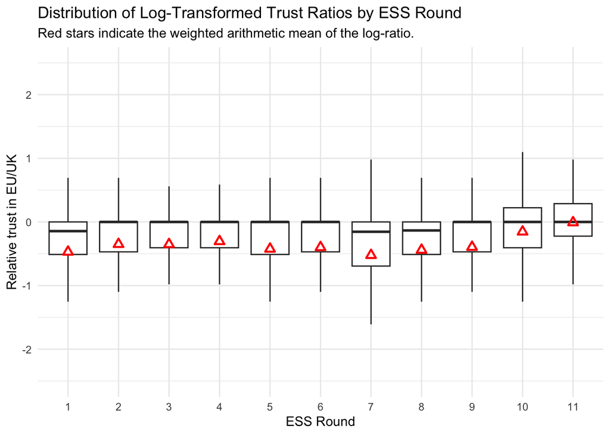

```r
ggplot(target_explore, aes(x = factor(essround), y = target_ratiolog)) +
  geom_boxplot(outlier.shape = NA) + # Hide outliers from boxplot if you prefer to show them with geom_jitter
 # geom_jitter(aes(size = anweight), alpha = 0.3, width = 0.2, color = "blue") + # Plot individual points, sized by weight
  geom_point(data = weighted_avg_targetratio, aes(x = factor(essround), y = target_ratiolog),
             color = "red", shape = 24, size = 2, stroke = 1.2) + # Add weighted average as a red star
  labs(
    title = "Distribution of Log-Transformed Trust Ratios by ESS Round",
    subtitle = "Red stars indicate the weighted arithmetic mean of the log-ratio.",
    x = "ESS Round",
    y = "Relative trust in EU/UK") +
  theme_minimal()+
  lims(y = c(-2.5,2.5))
```

Plot of just the exponentialised variable.

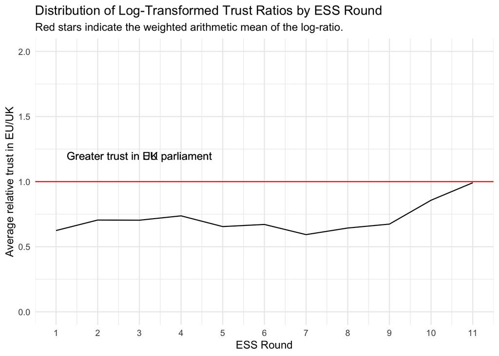

```r
ggplot(weighted_avg_targetratio,
       aes(x = essround, y = target_interp)) +
  geom_line() +
  lims(y = c(0,2))+
  scale_x_continuous(breaks = seq(1,11,1))+
  geom_hline(yintercept =  1, colour = "red")+
  labs(
    title = "Distribution of Log-Transformed Trust Ratios by ESS Round",
    subtitle = "Red stars indicate the weighted arithmetic mean of the log-ratio.",
    x = "ESS Round",
    y = "Average relative trust in EU/UK") +
  theme_minimal()+
  annotate(geom="text",
           x = 3, y = 1.2, label = "Greater trust in EU parliament")+ # UK trust label
  annotate(geom="text",
           x = 3, y = 1.2, label = "Greater trust in UK parliament")+ # UK trust label
  annotate(geom = "segment",
    x = 5,                    # X-coordinate of the arrow's tail
    y = 6,                    # Y-coordinate of the arrow's tail
    xend = 5,                 # X-coordinate of the arrow's head (same as x for vertical)
    yend = 7,                 # Y-coordinate of the arrow's head (higher than y for upward)
    arrow = arrow(length = unit(0.3, "cm"), type = "closed"), # Define the arrow properties
    color = "red",            # Color of the arrow
    lwd = 1                   # Line width (thickness) of the arrow
  )
```

Plot of simple difference:

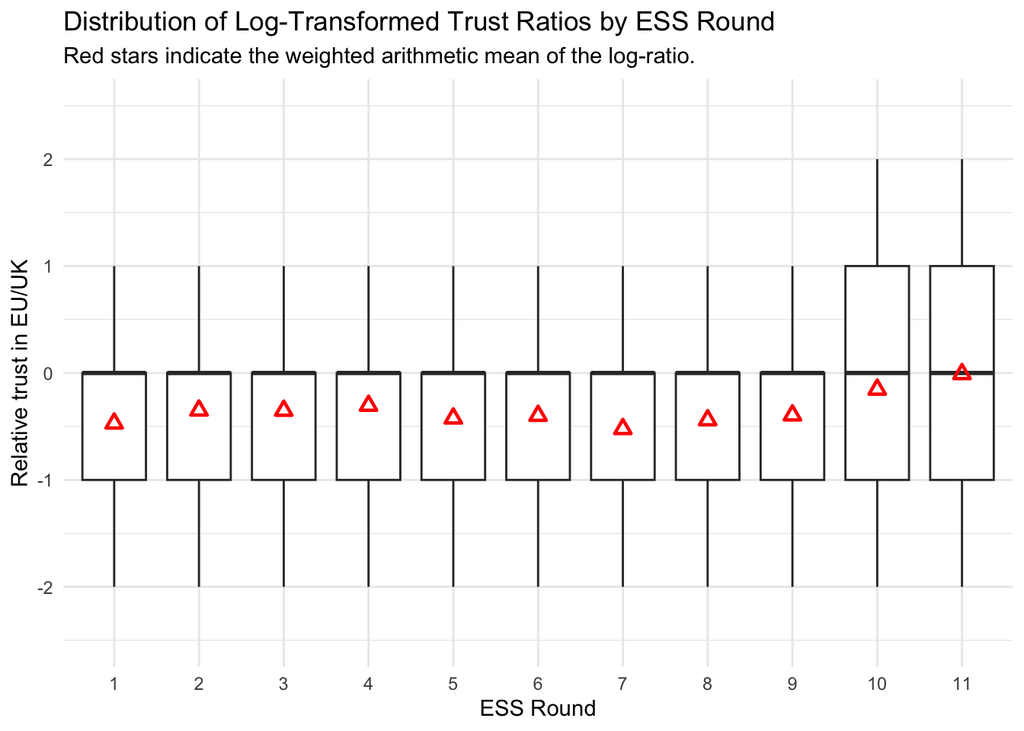

```r
ggplot(target_explore, aes(x = factor(essround), y = target_diff)) +
  geom_boxplot(outlier.shape = NA) + # Hide outliers from boxplot if you prefer to show them with geom_jitter
 # geom_jitter(aes(size = anweight), alpha = 0.3, width = 0.2, color = "blue") + # Plot individual points, sized by weight
  geom_point(data = weighted_avg_targetratio, aes(x = factor(essround), y = target_ratiolog),
             color = "red", shape = 24, size = 2, stroke = 1.2) + # Add weighted average as a red star
  labs(
    title = "Distribution of Log-Transformed Trust Ratios by ESS Round",
    subtitle = "Red stars indicate the weighted arithmetic mean of the log-ratio.",
    x = "ESS Round",
    y = "Relative trust in EU/UK") +
  theme_minimal()+
  lims(y = c(-2.5,2.5))
```

### Calculate weighted averages by round

```r
# Create a survey design object
simple_design <- target_explore |>
  as_survey_design(ids = 1, weights = anweight)

# Calculate weighted proportions of target_diff_cat for each essround
weighted_targ_proportions <- simple_design |>
  group_by(essround, target_diff_cat) |>  # Group by both variables
  summarise(
    # Use survey_prop() to get the weighted proportion
    proportion = survey_prop(vartype = c("se", "ci")), # Also get standard errors and confidence intervals
    .groups = 'drop'
  )
```

```
## When `proportion` is unspecified, `survey_prop()` now defaults to `proportion = TRUE`.
## ℹ This should improve confidence interval coverage.
```

```r
# Check data
weighted_targ_proportions
```

| essround | target_diff_cat | proportion | proportion_se | proportion_low | proportion_upp |
| --- | --- | --- | --- | --- | --- |
| 1 | Greater UK support | 0.5526055 | 0.01286505 | 0.5272750 | 0.5776659 |
| 1 | Equal support | 0.2512302 | 0.01121014 | 0.2299014 | 0.2738341 |
| 1 | Greater EU support | 0.1961643 | 0.01027172 | 0.1768081 | 0.2170807 |
| 2 | Greater UK support | 0.5072831 | 0.01396471 | 0.4799166 | 0.5346060 |
| 2 | Equal support | 0.2639642 | 0.01202028 | 0.2410863 | 0.2881886 |
| 2 | Greater EU support | 0.2287527 | 0.01206476 | 0.2059674 | 0.2532548 |
| 3 | Greater UK support | 0.5052994 | 0.01243771 | 0.4809272 | 0.5296465 |
| 3 | Equal support | 0.2720707 | 0.01106841 | 0.2509248 | 0.2942984 |
| 3 | Greater EU support | 0.2226299 | 0.01041141 | 0.2028912 | 0.2437019 |
| 4 | Greater UK support | 0.4966691 | 0.01228008 | 0.4726255 | 0.5207282 |

[output cut: 23 more lines]

```r
# cehck each round is 100% proportion.
weighted_targ_proportions |>
  group_by(essround) |> summarise(totalobs = sum(proportion))
```

| essround | totalobs |
| --- | --- |
| 1 | 1 |
| 2 | 1 |
| 3 | 1 |
| 4 | 1 |
| 5 | 1 |
| 6 | 1 |
| 7 | 1 |
| 8 | 1 |
| 9 | 1 |
| 10 | 1 |

[output cut: 1 more lines]

## Plot the trends - for report

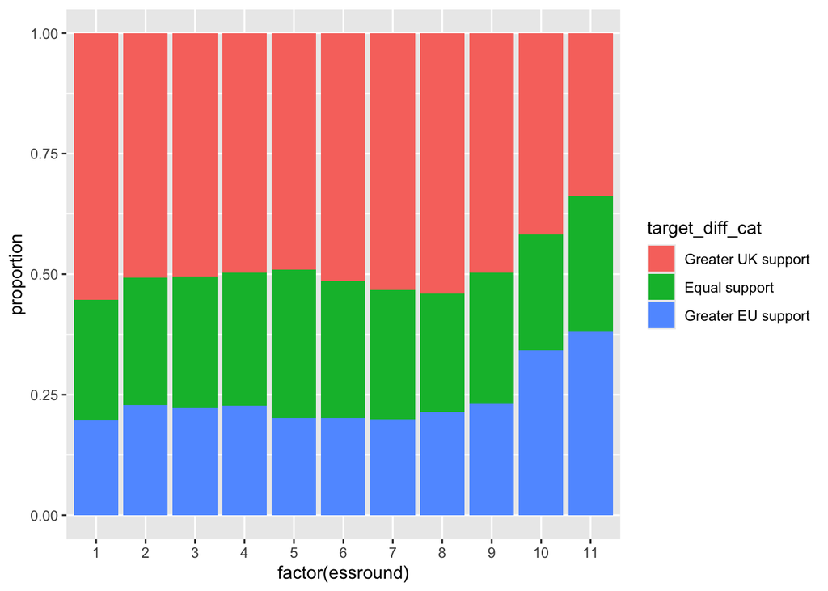

```r
# stacked bar plots
weighted_targ_proportions |>
  ggplot(aes(x=factor(essround), y = proportion, group = target_diff_cat, fill = target_diff_cat))+
  geom_col()
```

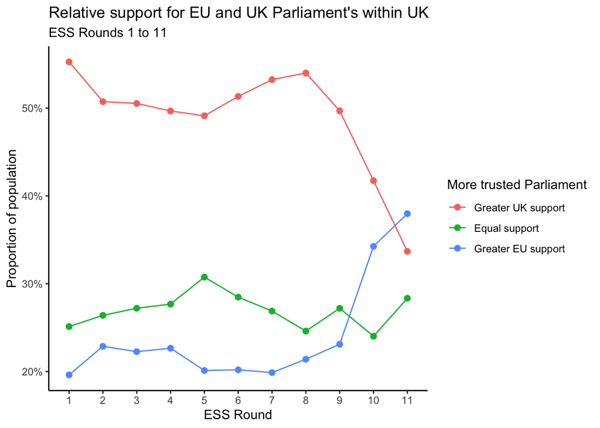

```r
# line chart.
weighted_targ_proportions |>
  ggplot(aes(x=factor(essround), y = proportion, group = target_diff_cat, colour = target_diff_cat))+
  geom_line()+
  geom_point(size=2)+
  # geom_errorbar(aes(ymin = proportion_low, ymax = proportion_upp),
  #               width = 0.5, colour = "gray")+
  theme_classic()+
  labs(title = "Relative support for EU and UK Parliament's within UK",
       subtitle = "ESS Rounds 1 to 11",
       y = "Proportion of population",
       x = "ESS Round",
       colour = "More trusted Parliament")+
    scale_y_continuous(labels = scales::percent)
```

## Response rates plot

Here we manually impute the response rates from round 6 to 10 and then match against the number of responeses. The response numbers are taken from each rounds quality report on the ESS website. Pre-round 6 data not found but is reported in this paper: https://surveyinsights.org/?p=9673.

The sampling during the COVID-19 period for rounds 10 and 11 in the regression models are important considerations. While weightings help balance data, the response rate for the UK dropped from • 50.6% in Round 6 • 43.6% in Round 7, • 43.0% in Round 8 • 41.0% in Round 9 • 20.9% in Round 10 • All sourced from ESS quality reports for each round, Round 11 information not available yet. • While robustness testing can be conducted to understand those respond “don’t know” to the target variable.

Add in summary table to use:

```r
gb_rr_testing <- ess_data |>
  filter(cntry == "GB",
         essround >5) |>
  select(
    essround,
    cntry,
    #trust_people = ppltrst,
    trust_europ,
    trust_parliament)
```

```r
#count total responses.
total_responses <- gb_rr_testing |>
  group_by(essround) |> summarise(total_responses = n())

# summary of response rates
response_rates <- as_tibble(list(
  essround = c(6, 7, 8, 9, 10, 11),
  resp_rate = c(0.506, 0.436, 0.430, 0.410, 0.209, NA)
))

# join together
total_responses <- total_responses |>
  left_join(response_rates, by = join_by(essround))
```

Tranform dataset longer:

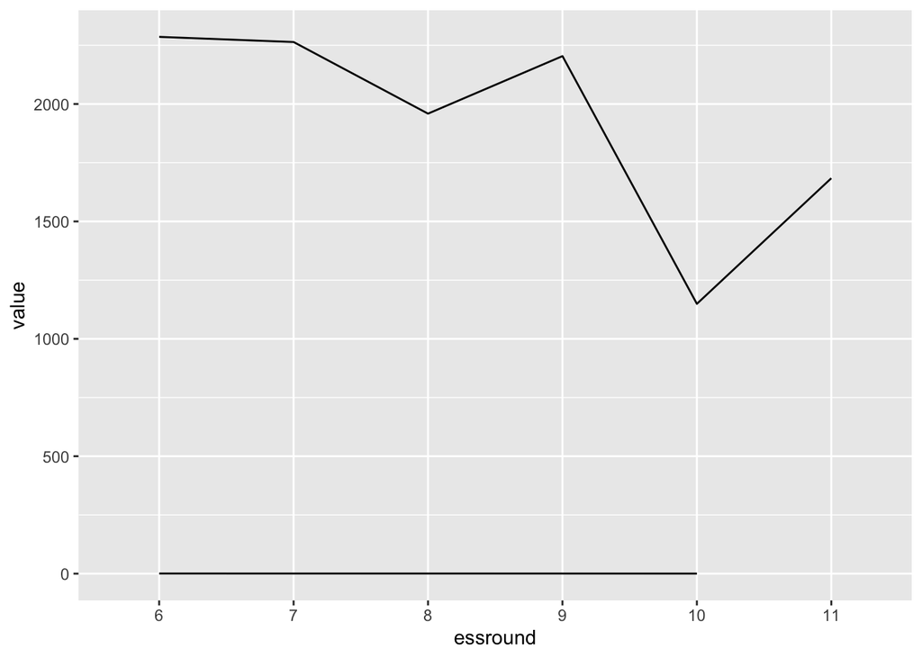

```r
total_responses |>
  pivot_longer(cols = c(resp_rate, total_responses),
               names_to = "Variable") |>
  mutate(essround = factor(essround)) |>
  ggplot(aes(x=essround, y = value, group = Variable))+
  geom_line()
```

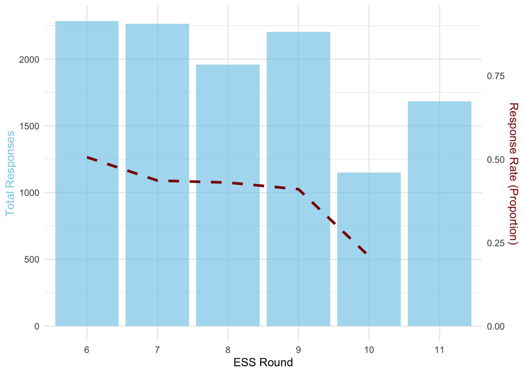

```r
# Store variables for easy reference
max_total <- max(total_responses$total_responses)
max_rate <- max(total_responses$resp_rate)

# Calculate a scaling factor
scale_factor <- max_total / max_rate

# Plot
total_responses |>
  ggplot(aes(x = factor(essround))) +

  # Total responses: Left axis (primary)
  geom_col(aes(y = total_responses), fill = "skyblue", alpha = 0.7) +

  # Response rate: Right axis (secondary), scaled
  geom_line(aes(y = resp_rate*2500),
            color = "darkred",
            size = 1.2,
            linetype = "dashed",
            group = 1) +

  scale_y_continuous(
    name = "Total Responses",
    sec.axis = sec_axis(~ . / 2500, name = "Response Rate (Proportion)")
  ) +

  labs(x = "ESS Round") +
  theme_minimal() +
  theme(
    axis.title.y = element_text(color = "skyblue"),
    axis.title.y.right = element_text(color = "darkred")
  )
```

### Check NA responses

```r
gb_rr_testing |>
  mutate(na_eu = ifelse(is.na(trust_europ), 1,0),
         na_uk_parl = ifelse(is.na(trust_parliament), 1,0)) |>
  group_by(essround) |>
  summarise(obs = n(),
            total_euNA = sum(na_eu),
            total_ukNA = sum(na_uk_parl),
            pct_euNA = round(total_euNA/obs*100,2),
            pct_ukNA = round(total_ukNA/obs*100,2))
```

| essround | obs | total_euNA | total_ukNA | pct_euNA | pct_ukNA |
| --- | --- | --- | --- | --- | --- |
| 6 | 2286 | 358 | 67 | 15.66 | 2.93 |
| 7 | 2264 | 166 | 37 | 7.33 | 1.63 |
| 8 | 1959 | 97 | 20 | 4.95 | 1.02 |
| 9 | 2204 | 103 | 22 | 4.67 | 1.00 |
| 10 | 1149 | 53 | 8 | 4.61 | 0.70 |
| 11 | 1684 | 249 | 42 | 14.79 | 2.49 |